# Bird Strike Data Analysis

## Introduction

> A bird strike can be defined as a collision between a bird and an aircraft that is in flight or on a take-off or landing roll. They are a major problem worldwide because they threaten passenger safety and result in costly repairs and lost revenue for the commercial air carrier.

> The dataset used for this analysis contains bird strike cases from 1990 to 2021 in the United States and the bird strike cases that caused damage to the aircraft were 13593 out of 45039 bird strike cases.

```python
from IPython import display
```

[figure not shown]

```python
display.Image("birdstrike.png")
```

## Data dictionary

> AMO: International Civil Aviation Organization code for Aircraft Model

> EMA: Engine Make Code

> EMO: Engine Model Code

> AC_CLASS: Type of aircraft

> AC_MASS: 1 = 2,250 kg or less: 2 = ,2251-5700 kg: 3 = 5,701-27,000 kg: 4 = 27,001-272,000 kg: 5 = above 272,000 kg

> NUM_ENGS: Number of engines

> TYPE_ENG: Type of power A = reciprocating engine (piston): B = Turbojet: C = Turboprop: D = Turbofan: E = None (glider): F = Turboshaft (helicopter): Y = Other

> ENG_1_POS: Where engine # 1 is mounted on aircraft

> ENG_2_POS: Where engine # 2 is mounted on aircraft

> DAY: Day strike occurred

> MONTH: Month strike occurred

> YEAR: Year strike occurred

> TIME_HOUR: Hour in local time

> TIME_MIN: Minute in local time

> FAAREGION: FAA Region where airport is located

> HEIGHT: Feet Above Ground Level

> DISTANCE: Nautical miles from airport

> PHASE_OF_FLT: Phase of flight during which strike occurred

> INGESTED: Engine ingested the bird/ animal

> SKY: Type of cloud cover, if any

> PRECIP: Precipitation

> SPECIES: Common name for bird or other wildlife

> INDICATED_DAMAGE: Indicates whether or not aircraft was damaged

> SIZE: Size of bird as reported by pilot is a relative scale. Entry should reflect the perceived size as opposed to a scientifically determined value. If more than one species was struck, larger bird is entered.

```python
# import all packages and set plots to be embedded inline
import numpy as np
import pandas as pd
import matplotlib.pyplot as plt
import seaborn as sb

%matplotlib inline
```

## Data Gathering

```python
#Loading in the data
birdstrike_data = pd.read_csv('birdstrike.csv')
birdstrike_data.head()
```

|  | AC_MASS | STATE | SIZE | FAAREGION | AC_CLASS | AIRPORT | LATITUDE | LONGITUDE | OPERATOR | AIRCRAFT | ... | INGESTED | SPECIES | DAY | MONTH | YEAR | DAY_NAME | MONTH_NAME | TIME_HOUR | TIME_MIN | INDICATED_DAMAGE |
| --- | --- | --- | --- | --- | --- | --- | --- | --- | --- | --- | --- | --- | --- | --- | --- | --- | --- | --- | --- | --- | --- |
| 0 | 4 | CO | Small | ANM | A | DENVER INTL AIRPORT | 39.85841 | -104.66700 | SOUTHWEST AIRLINES | B-737-300 | ... | False | European starling | 5 | 8 | 2012 | Sunday | August | 8 | 0 | False |
| 1 | 4 | MO | Medium | ACE | A | LAMBERT-ST LOUIS INTL | 38.74769 | -90.35999 | AMERICAN AIRLINES | MD-80 | ... | False | Ducks | 10 | 1 | 2003 | Friday | January | 23 | 29 | False |
| 2 | 4 | CA | Large | ASO | A | JOHN GLENN COLUMBUS INTL ARPT | 37.13190 | -76.49299 | BUSINESS | MD-88 | ... | False | Horse | 22 | 9 | 2002 | Sunday | September | 8 | 0 | True |
| 3 | 3 | UT | Small | ANM | A | SALT LAKE CITY INTL | 40.78839 | -111.97777 | SKYWEST AIRLINES | CRJ100/200 | ... | False | Horned lark | 26 | 11 | 2003 | Wednesday | November | 7 | 52 | False |
| 4 | 4 | WA | Small | ANM | A | SEATTLE-TACOMA INTL | 47.44898 | -122.30931 | DELTA AIR LINES | B-757-200 | ... | False | Pacific-slope flycatcher | 6 | 8 | 2018 | Monday | August | 11 | 50 | False |

5 rows × 32 columns

## Data Assessing

```python
#Checking the datasets information
birdstrike_data.info()
```

```
<class 'pandas.core.frame.DataFrame'>
RangeIndex: 45039 entries, 0 to 45038
Data columns (total 32 columns):
AC_MASS             45039 non-null int64
STATE               45039 non-null object
SIZE                45039 non-null object
FAAREGION           45039 non-null object
AC_CLASS            45039 non-null object
AIRPORT             45039 non-null object
LATITUDE            45039 non-null float64
LONGITUDE           45039 non-null float64
OPERATOR            45039 non-null object
AIRCRAFT            45039 non-null object
AMO                 45039 non-null int64
EMA                 45039 non-null int64
EMO                 45039 non-null float64
TYPE_ENG            45039 non-null object
NUM_ENGS            45039 non-null int64
ENG_1_POS           45039 non-null int64
ENG_2_POS           45039 non-null int64
PHASE_OF_FLIGHT     45039 non-null object
HEIGHT              44973 non-null float64
DISTANCE            45039 non-null float64
SKY                 45039 non-null object
PRECIPITATION       45039 non-null object
INGESTED            45039 non-null bool
SPECIES             45039 non-null object
DAY                 45039 non-null int64
MONTH               45039 non-null int64
YEAR                45039 non-null int64
DAY_NAME            45039 non-null object
MONTH_NAME          45039 non-null object
TIME_HOUR           45039 non-null int64
TIME_MIN            45039 non-null int64
INDICATED_DAMAGE    45039 non-null bool
dtypes: bool(2), float64(5), int64(11), object(14)
memory usage: 10.4+ MB
```

```python
#Chcking the descriptive statistics of numerical variables
birdstrike_data.describe()
```

|  | AC_MASS | LATITUDE | LONGITUDE | AMO | EMA | EMO | NUM_ENGS | ENG_1_POS | ENG_2_POS | HEIGHT | DISTANCE | DAY | MONTH | YEAR | TIME_HOUR | TIME_MIN |
| --- | --- | --- | --- | --- | --- | --- | --- | --- | --- | --- | --- | --- | --- | --- | --- | --- |
| count | 45039.000000 | 45039.000000 | 45039.000000 | 45039.000000 | 45039.000000 | 45039.000000 | 45039.000000 | 45039.000000 | 45039.000000 | 44973.000000 | 45039.000000 | 45039.000000 | 45039.000000 | 45039.000000 | 45039.000000 | 45039.000000 |
| mean | 3.342992 | 37.434647 | -93.463714 | 25.551589 | 18.805213 | 6.840161 | 1.928728 | 2.997269 | 2.582695 | 1526.532786 | 11.404879 | 16.071027 | 6.862541 | 2010.991874 | 13.053642 | 26.107684 |
| std | 1.065774 | 5.928858 | 17.949748 | 20.348173 | 10.704680 | 7.536327 | 0.401804 | 2.259158 | 1.945159 | 2119.202880 | 13.527866 | 8.422093 | 3.144209 | 7.594453 | 5.550695 | 17.649641 |
| min | 1.000000 | 22.093875 | -141.403170 | 0.000000 | 0.000000 | 0.000000 | 1.000000 | 1.000000 | 1.000000 | 0.000000 | 0.000000 | 1.000000 | 1.000000 | 1990.000000 | 0.000000 | 0.000000 |
| 25% | 3.000000 | 33.640440 | -104.700250 | 7.000000 | 10.000000 | 1.000000 | 2.000000 | 1.000000 | 1.000000 | 60.000000 | 2.000000 | 9.000000 | 4.000000 | 2006.000000 | 9.000000 | 10.000000 |
| 50% | 4.000000 | 38.834110 | -88.773750 | 24.000000 | 19.000000 | 4.000000 | 2.000000 | 1.000000 | 1.000000 | 700.000000 | 5.000000 | 16.000000 | 7.000000 | 2013.000000 | 12.000000 | 27.000000 |
| 75% | 4.000000 | 41.302520 | -80.290560 | 42.000000 | 31.000000 | 10.000000 | 2.000000 | 5.000000 | 5.000000 | 2000.000000 | 15.000000 | 23.000000 | 9.000000 | 2017.000000 | 18.000000 | 40.000000 |
| max | 5.000000 | 52.884715 | -43.440050 | 98.000000 | 47.000000 | 23.500000 | 4.000000 | 7.000000 | 7.000000 | 11000.000000 | 60.000000 | 31.000000 | 12.000000 | 2021.000000 | 23.000000 | 59.000000 |

```python
#Checking for duplicated rows
birdstrike_data.duplicated().sum()
```

```
0
```

```python
#Checking the shape of the dataset
birdstrike_data.shape
```

```
(45039, 32)
```

```python
#Getting five random entries of the dataset
birdstrike_data.sample(5)
```

|  | AC_MASS | STATE | SIZE | FAAREGION | AC_CLASS | AIRPORT | LATITUDE | LONGITUDE | OPERATOR | AIRCRAFT | ... | INGESTED | SPECIES | DAY | MONTH | YEAR | DAY_NAME | MONTH_NAME | TIME_HOUR | TIME_MIN | INDICATED_DAMAGE |
| --- | --- | --- | --- | --- | --- | --- | --- | --- | --- | --- | --- | --- | --- | --- | --- | --- | --- | --- | --- | --- | --- |
| 30338 | 4 | CA | Medium | ASO | A | GRANT COUNTY ARPT | 39.29761 | -94.71391 | 1US AIRWAYS | B-737-300 | ... | False | Mourning dove | 24 | 8 | 1998 | Monday | August | 19 | 5 | True |
| 16136 | 2 | NC | Small | ASO | A | CONCORD REGIONAL ARPT | 35.38521 | -80.70971 | BUSINESS | EMB PHENOM 100 | ... | True | Cedar waxwing | 19 | 11 | 2017 | Sunday | November | 16 | 20 | False |
| 10856 | 4 | CA | Large | AWP | A | SACRAMENTO INTL | 38.69542 | -121.59077 | SOUTHWEST AIRLINES | B-737-300 | ... | False | Greater white-fronted goose | 18 | 10 | 2016 | Tuesday | October | 19 | 45 | False |
| 20191 | 3 | IL | Small | AGL | A | QUAD CITY ARPT | 41.44853 | -90.50754 | SKYWEST AIRLINES | EMB-145 | ... | False | Microbats | 11 | 6 | 2015 | Thursday | June | 21 | 35 | False |
| 21762 | 4 | WI | Small | AGL | A | OUTAGAMIE COUNTY REGIONAL | 44.25741 | -88.51948 | FEDEX EXPRESS | A-300 | ... | False | Killdeer | 25 | 5 | 2018 | Friday | May | 6 | 10 | False |

5 rows × 32 columns

```python
#Checking the value counts of the indicated_damage column
birdstrike_data.INDICATED_DAMAGE.value_counts()
```

```
False    31446
True     13593
Name: INDICATED_DAMAGE, dtype: int64
```

```python
#Checking the top 10 value counts of the airport column
birdstrike_data.AIRPORT.value_counts().head(10)
```

```
DENVER INTL AIRPORT                       1370
SALT LAKE CITY INTL                       1244
DALLAS/FORT WORTH INTL ARPT               1235
SACRAMENTO INTL                           1175
JOHN F KENNEDY INTL                        918
CHICAGO O'HARE INTL ARPT                   809
LA GUARDIA ARPT                            790
LOS ANGELES INTL                           742
KANSAS CITY INTL                           707
HARTSFIELD - JACKSON ATLANTA INTL ARPT     689
Name: AIRPORT, dtype: int64
```

```python
#Checking the top 10 value counts of the species column
birdstrike_data.SPECIES.value_counts().head(10)
```

```
Mourning dove        2746
Gulls                2696
Barn swallow         2547
European starling    1746
Horned lark          1619
American kestrel     1529
Killdeer             1362
Red-tailed hawk      1362
Rock pigeon          1321
Sparrows             1148
Name: SPECIES, dtype: int64
```

```python
#Checking the top 10 value counts of the operator column
birdstrike_data.OPERATOR.value_counts().head(10)
```

```
BUSINESS              11170
SOUTHWEST AIRLINES     6041
AMERICAN AIRLINES      5183
DELTA AIR LINES        4956
UNITED AIRLINES        4050
SKYWEST AIRLINES       2850
PRIVATELY OWNED        1981
JETBLUE AIRWAYS        1897
FEDEX EXPRESS          1433
ALASKA AIRLINES        1222
Name: OPERATOR, dtype: int64
```

## Observation

### Data Cleaning

```python
#Making a copy of the dataset
bird_strike = birdstrike_data.copy()
```

### Issue 1: The height column contains null values

#### Define: Replacing the null values in the height column with the mean

#### Code

```python
#Filling the null values in the height column with the mean_height
mean_height = round(bird_strike.HEIGHT.mean())
bird_strike.HEIGHT.fillna(mean_height, inplace = True)
```

#### Test

```python
#Checking for null values in the height column
bird_strike.isna().sum()
```

```
AC_MASS             0
STATE               0
SIZE                0
FAAREGION           0
AC_CLASS            0
AIRPORT             0
LATITUDE            0
LONGITUDE           0
OPERATOR            0
AIRCRAFT            0
AMO                 0
EMA                 0
EMO                 0
TYPE_ENG            0
NUM_ENGS            0
ENG_1_POS           0
ENG_2_POS           0
PHASE_OF_FLIGHT     0
HEIGHT              0
DISTANCE            0
SKY                 0
PRECIPITATION       0
INGESTED            0
SPECIES             0
DAY                 0
MONTH               0
YEAR                0
DAY_NAME            0
MONTH_NAME          0
TIME_HOUR           0
TIME_MIN            0
INDICATED_DAMAGE    0
dtype: int64
```

### Issue 2: Columns with erroneous data types (AC_MASS, STATE, SIZE, FAAREGION, AC_CLASS, OPERATOR, TYPE_ENG, NUM_ENGS, PHASE_OF_FLIGHT, SKY, PRECIPITATION. DAY_NAME and MONTH_NAME

#### Define: Changing the erroneous data types to their correct datatype

#### Code

```python
#Changing the data types of some features
bird_strike[['AC_MASS', 'STATE', 'SIZE', 'FAAREGION', 'AC_CLASS', 'OPERATOR', 'ENG_1_POS', 'ENG_2_POS', 'TYPE_ENG', 'NUM_ENGS', 'PHASE_OF_FLIGHT', 'SKY', 'PRECIPITATION', 'DAY_NAME', 'MONTH_NAME']] = bird_strike[['AC_MASS', 'STATE', 'SIZE', 'FAAREGION', 'AC_CLASS', 'OPERATOR', 'ENG_1_POS', 'ENG_2_POS', 'TYPE_ENG', 'NUM_ENGS', 'PHASE_OF_FLIGHT', 'SKY', 'PRECIPITATION', 'DAY_NAME', 'MONTH_NAME']].astype('category')
```

#### Test

```python
#Checking for the datatypes of some columns
bird_strike.info()
```

```
<class 'pandas.core.frame.DataFrame'>
RangeIndex: 45039 entries, 0 to 45038
Data columns (total 32 columns):
AC_MASS             45039 non-null category
STATE               45039 non-null category
SIZE                45039 non-null category
FAAREGION           45039 non-null category
AC_CLASS            45039 non-null category
AIRPORT             45039 non-null object
LATITUDE            45039 non-null float64
LONGITUDE           45039 non-null float64
OPERATOR            45039 non-null category
AIRCRAFT            45039 non-null object
AMO                 45039 non-null int64
EMA                 45039 non-null int64
EMO                 45039 non-null float64
TYPE_ENG            45039 non-null category
NUM_ENGS            45039 non-null category
ENG_1_POS           45039 non-null category
ENG_2_POS           45039 non-null category
PHASE_OF_FLIGHT     45039 non-null category
HEIGHT              45039 non-null float64
DISTANCE            45039 non-null float64
SKY                 45039 non-null category
PRECIPITATION       45039 non-null category
INGESTED            45039 non-null bool
SPECIES             45039 non-null object
DAY                 45039 non-null int64
MONTH               45039 non-null int64
YEAR                45039 non-null int64
DAY_NAME            45039 non-null category
MONTH_NAME          45039 non-null category
TIME_HOUR           45039 non-null int64
TIME_MIN            45039 non-null int64
INDICATED_DAMAGE    45039 non-null bool
dtypes: bool(2), category(15), float64(5), int64(7), object(3)
memory usage: 5.9+ MB
```

### FEATURE ENGINEERING

```python
#Checking the unique values in the month column
bird_strike.MONTH.unique()
```

```
array([ 8,  1,  9, 11,  4,  7,  2, 12,  3, 10,  6,  5])
```

```python
#Assigning winter, summer, fall and spring to different months
seasons = {1: 'Winter', 2: 'Winter', 3: 'Spring', 4:'Spring', 5: 'Spring', 6: 'Summer', 7: 'Summer', 8:'Summer', 9: 'Fall', 10: 'Fall', 11: 'Fall', 12: 'Winter'}
bird_strike['SEASON'] = bird_strike['MONTH'].apply(lambda x: seasons[x])
```

```python
#Checking the unique values of the new feature (season)
bird_strike['SEASON'].unique()
```

```
array(['Summer', 'Winter', 'Fall', 'Spring'], dtype=object)
```

```python
bird_strike.head()
```

|  | AC_MASS | STATE | SIZE | FAAREGION | AC_CLASS | AIRPORT | LATITUDE | LONGITUDE | OPERATOR | AIRCRAFT | ... | SPECIES | DAY | MONTH | YEAR | DAY_NAME | MONTH_NAME | TIME_HOUR | TIME_MIN | INDICATED_DAMAGE | SEASON |
| --- | --- | --- | --- | --- | --- | --- | --- | --- | --- | --- | --- | --- | --- | --- | --- | --- | --- | --- | --- | --- | --- |
| 0 | 4 | CO | Small | ANM | A | DENVER INTL AIRPORT | 39.85841 | -104.66700 | SOUTHWEST AIRLINES | B-737-300 | ... | European starling | 5 | 8 | 2012 | Sunday | August | 8 | 0 | False | Summer |
| 1 | 4 | MO | Medium | ACE | A | LAMBERT-ST LOUIS INTL | 38.74769 | -90.35999 | AMERICAN AIRLINES | MD-80 | ... | Ducks | 10 | 1 | 2003 | Friday | January | 23 | 29 | False | Winter |
| 2 | 4 | CA | Large | ASO | A | JOHN GLENN COLUMBUS INTL ARPT | 37.13190 | -76.49299 | BUSINESS | MD-88 | ... | Horse | 22 | 9 | 2002 | Sunday | September | 8 | 0 | True | Fall |
| 3 | 3 | UT | Small | ANM | A | SALT LAKE CITY INTL | 40.78839 | -111.97777 | SKYWEST AIRLINES | CRJ100/200 | ... | Horned lark | 26 | 11 | 2003 | Wednesday | November | 7 | 52 | False | Fall |
| 4 | 4 | WA | Small | ANM | A | SEATTLE-TACOMA INTL | 47.44898 | -122.30931 | DELTA AIR LINES | B-757-200 | ... | Pacific-slope flycatcher | 6 | 8 | 2018 | Monday | August | 11 | 50 | False | Summer |

5 rows × 33 columns

##### What is the structure of your dataset?

> This dataset contains 45039 bird strike cases with 33 features (Airport, Aircraft, Time_hour, Species, etc.).

### What is/are the main feature(s) of interest in your dataset?

> The main feature of interest in this dataset is Indicated_damage. The Indicated damage feature tells whether the aircraft was damaged or not and so I want to carry out further analysis to find relationship between the Indicated_damage and other variables.

### What features in the dataset do you think will help support your investigation into your feature(s) of interest?

> The Species, Time, Season, Airport, State, Distance, Height, Longitude, Latitude, Year and Size would help me in my investigation.

## Univariate Exploration

> In this section, I will be investigating distributions of individual variables.

## Question 1: What percent of the bird strike cases caused damage to the aircraft?

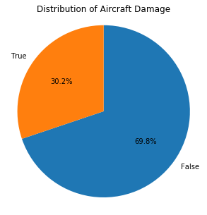

```python
plt.figure(figsize = [12, 5])

damage_counts = bird_strike['INDICATED_DAMAGE'].value_counts()
plt.pie(damage_counts, labels = damage_counts.index, startangle = 90, counterclock = False, autopct='%1.1f%%');
plt.title('Distribution of Aircraft Damage')
plt.axis('square');
#The plot below shows distribution of aircraft damage caused by bird strikes
```

### Observation

There was a high percentage of bird strikes but only 30.2% caused damage to the aircraft from the plot above.

## Question 2: What season, months and year do birds attack the most?

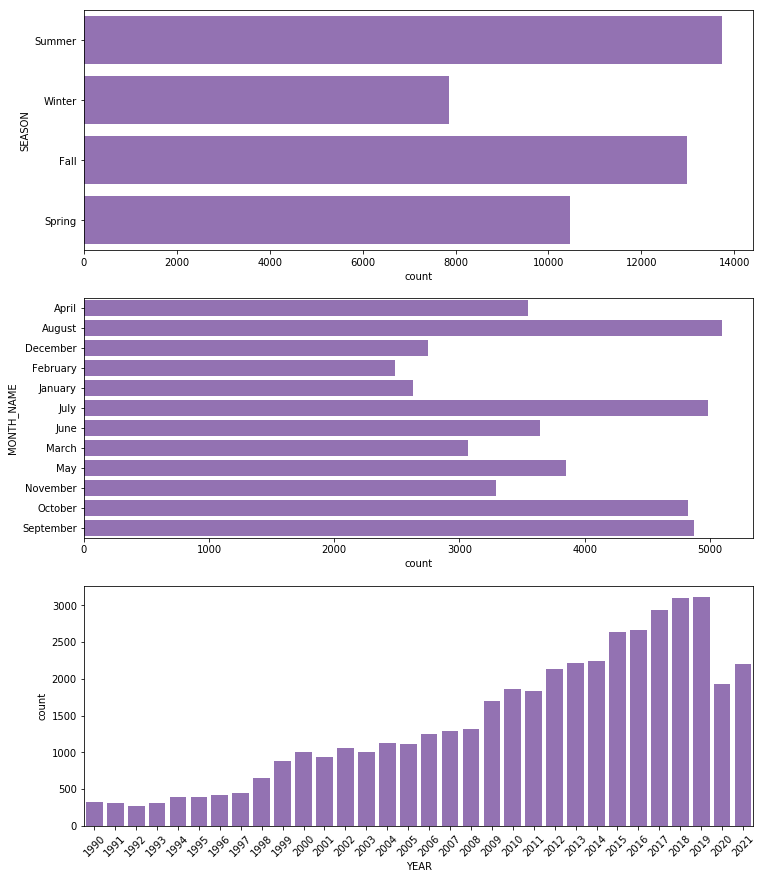

```python
fig, ax = plt.subplots(nrows=3, figsize = [12,15])

base_color = sb.color_palette()[4]
sb.countplot(data = bird_strike, y = 'SEASON', color = base_color, ax = ax[0])
sb.countplot(data = bird_strike, y = 'MONTH_NAME', color = base_color, ax = ax[1])
sb.countplot(data = bird_strike, x = 'YEAR', color = base_color, ax = ax[2])
plt.xticks(rotation = 45)
plt.show()
#The plots below shows the different distribution of season , month and year
```

### Observation

Bird strikes least occurred in the year 1992 and occurred most in the year 2018 and 2019 which was the peak. It decreased again in the year 2020 and that could be as a result of covid which affected people's travelling rate. It can also be seen from the plot that there was a slight increase in 2021 as people resume traveling. July and August had the most bird strikes which is also the summer (June, July, and August) period.

## Question 3: At what time, distance and height do birds strike the most?

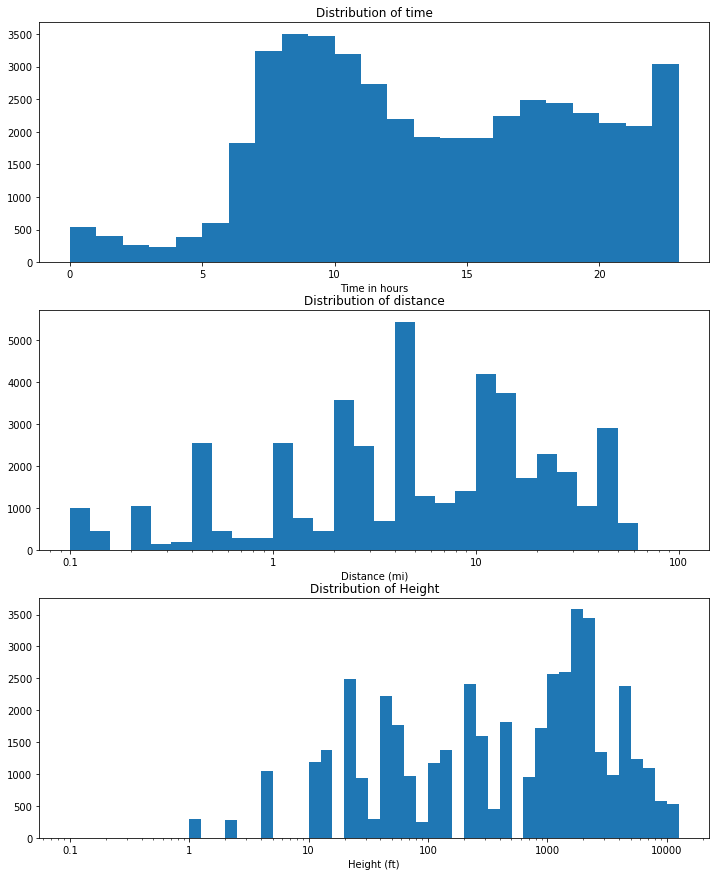

```python
plt.figure(figsize = [12,15])

#Function for histogram plots
def hist_plot(plot, x, y, df_name, df_var, Xlabel, Ylabel, Title):
    plot
    bin_x = np.arange(x, df_name[df_var].max()+y, y)
    plt.hist(data = df_name, x = df_var, bins = bin_x)
    plt.xlabel(Xlabel)
    plt.ylabel(Ylabel)
    plt.title(Title);

hist_plot(plt.subplot(3, 1, 1), 0, 1, bird_strike, 'TIME_HOUR', 'Time in hours', '', 'Distribution of time')

#Function for log hist plots
def feature_log(plot, bin_x, df_name, df_var, tick_x, Xlabel, Ylabel, TITLE):
    plot
    bin_x
    plt.hist(data = df_name, x = df_var, bins = bin_x)
    tick_x
    labels = ['{}'.format(v) for v in tick_x]
    plt.xscale('log')
    plt.xticks(tick_x, labels)
    plt.xlabel(Xlabel)
    plt.ylabel(Ylabel)
    plt.title(TITLE)

feature_log(plt.subplot(3, 1, 2), 10 **np.arange(-1, 2+0.1, 0.1), bird_strike, 'DISTANCE', [0.1, 1, 10, 100],
            'Distance (mi)', '', 'Distribution of distance' )
feature_log(plt.subplot(3, 1, 3), 10 **np.arange(-1, 4.05+0.1, 0.1), bird_strike, 'HEIGHT', [0.1, 1, 10, 100, 1000, 10000],
            'Height (ft)', '', 'Distribution of Height' )
#The plots below shows the different distribution of time, distance and height
```

## Question 4: Which Airport and States had the most aircraft damages?

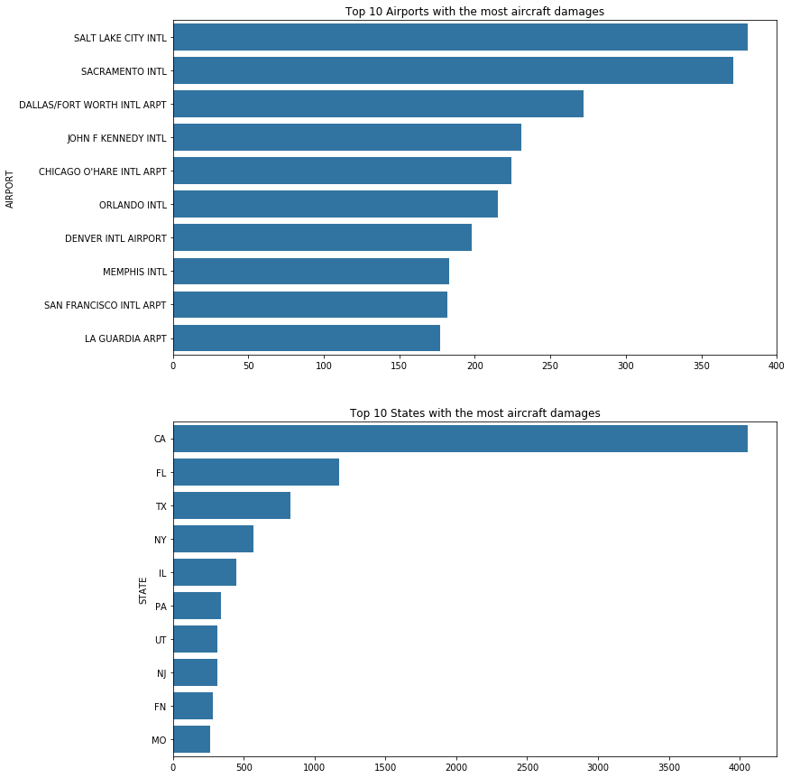

```python
plt.figure(figsize = [12, 15])
bird_strike_sub = bird_strike.query('INDICATED_DAMAGE == True')

#Function for barh charts
def feature_sub(plots, df, var, Title):
    plots
    default_color = sb.color_palette()[0]
    feature = df[var].value_counts().head(10)
    feature_order = feature.index
    feature_sub = df.loc[df[var].isin(feature_order)]
    sb.countplot(data = feature_sub, y = var, color = default_color, order = feature_order)
    plt.xlabel('')
    plt.title(Title);

feature_sub(plt.subplot(2, 1, 1), bird_strike_sub, 'AIRPORT', 'Top 10 Airports with the most aircraft damages')
feature_sub(plt.subplot(2, 1, 2), bird_strike_sub, 'STATE', 'Top 10 States with the most aircraft damages')
#The plots below shows the different distribution of airports and states with the most aircraft damages
```

### Observation

California State, Salt Lake City and Sacramento Intl airport were the states and airports with the most aircraft damages.

## Question 5: Which bird species and size of bird species caused the most bird strikes?

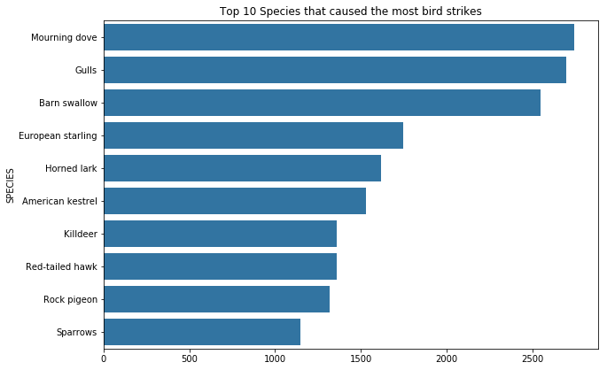

```python
plt.figure(figsize = [10, 15])
feature_sub(plt.subplot(2, 1, 1), bird_strike, 'SPECIES', 'Top 10 Species that caused the most bird strikes')
#The plots below shows the distribution of species that caused most bird strikes
```

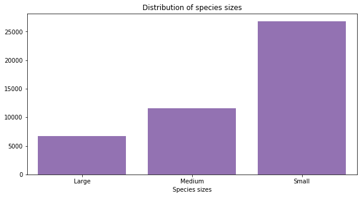

```python
plt.figure(figsize = [10,5])

#Function for bar plots
def barh_plot(name_df, var_y, Xlabel, Ylabel, Title):
    colors = sb.color_palette()[4]
    sb.countplot(data = name_df, x = var_y, color = colors)
    plt.xlabel(Xlabel)
    plt.ylabel(Ylabel)
    plt.title(Title);

barh_plot(bird_strike, 'SIZE', 'Species sizes', '', 'Distribution of species sizes')
#The plot below shows the distribution of species sizes that caused most bird strikes
```

### Observation

The species mourning dove and gulls were the bird species that caused the most bird strikes while the small sized birds striked the most.

## Question 6: Which bird species caused the most aircraft damages?

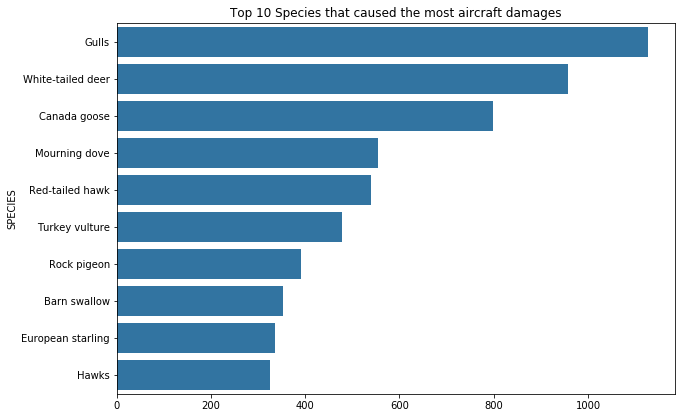

```python
plt.figure(figsize = [10,15])

feature_sub(plt.subplot(2, 1, 2), bird_strike_sub, 'SPECIES', 'Top 10 Species that caused the most aircraft damages')
#The plots below shows the distribution of species that caused most bird strikes
```

### Observation

The species gulls and white-tailed deer were the bird species that caused the most aircraft damages.

## Question 7: Aircrafts with what number of engines were the most popular?

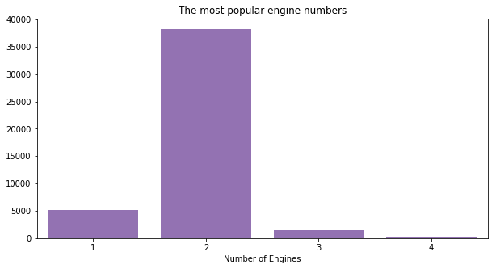

```python
plt.figure(figsize = [10,5])

barh_plot(bird_strike, 'NUM_ENGS', 'Number of Engines', '', 'The most popular engine numbers')
#The plot below shows the distribution of the most popular engine numbers
```

### Observation

Aircrafts with two engines were very popular while the ones with four engines were the least popular from the above plot.

## Question 8: At what latitude and longitude do birds strike?

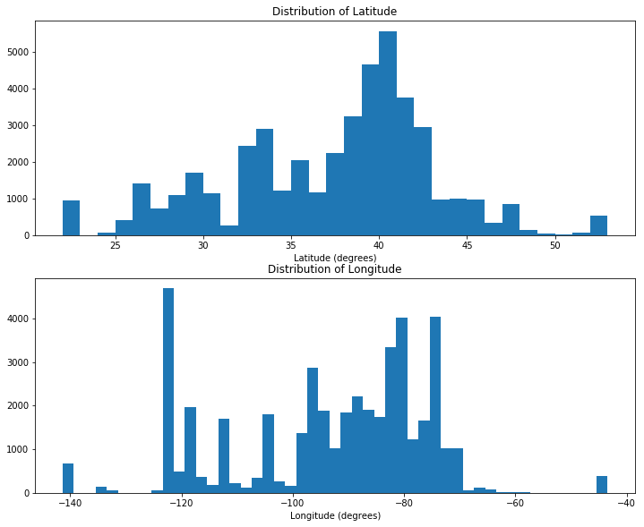

```python
plt.figure(figsize = [12,15])

hist_plot(plt.subplot(3, 1, 1), 22, 1, bird_strike, 'LATITUDE', 'Latitude (degrees)', '', 'Distribution of Latitude')
hist_plot(plt.subplot(3, 1, 2), min(bird_strike['LONGITUDE']), 2, bird_strike, 'LONGITUDE', 'Longitude (degrees)', '', 'Distribution of Longitude')
#The plots below shows the different distribution of latitude and longitude
```

### Observation

The longitude distribution is bimodal having its highest peak between -130 and -120 degrees while the latitude distribution is unimodal and left-skewed. From the plot, it can be deduced that at a longitude of -130 to -120 degrees and at a latitude of 40-43 degrees, birds strike the most.

### Discuss the distribution(s) of your variable(s) of interest. Were there any unusual points? Did you need to perform any transformations?

> Indicated damage is a categorical variable with two unique values (True and False). True depicts that the aircraft was damaged by bird strike while False depicts that the aircraft was not damaged by bird strike. There were lots of bird strike cases but only 30.2% caused damage to the aircraft.

### Of the features you investigated, were there any unusual distributions? Did you perform any operations on the data to tidy, adjust, or change the form of the data? If so, why did you do this?

> The distance and height feature had very high values and so I scaled the plot using log to account for those values. Also, the aircraft with 2 engines had a very high value counts compared to the other ones (1, 3 and 4).

## Bivariate Exploration

> In this section, I will be investigating relationships between pairs of variables in this data.

## Question 9: Which season had the most aircraft damages and bird strikes?

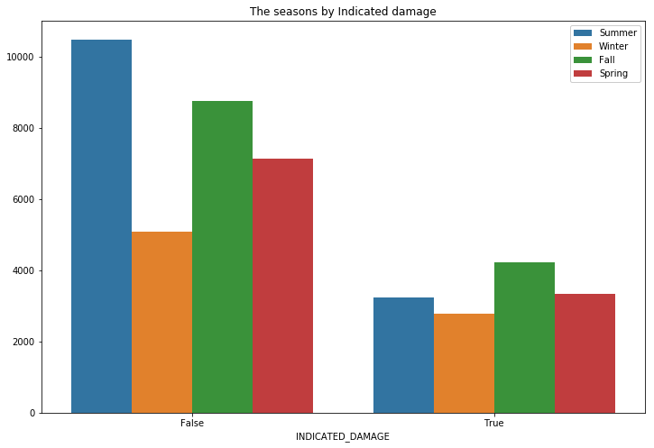

```python
plt.figure(figsize = [12, 8])

#Function for adapted barchart
def adapted_barchart(df, var, var_y, m, Title):
    ax = sb.countplot(data = df, x = var, hue = var_y)
    ax.legend(loc = m, framealpha = 1)
    plt.ylabel('')
    plt.title(Title);

adapted_barchart(bird_strike, 'INDICATED_DAMAGE', 'SEASON', 1, 'The seasons by Indicated damage')
#The plot below shows the different seasons by indicated damage.
```

### Observation

The plot depicts two things:

- Summer had the most bird strikes while winter had the least.
- Fall had the most aircraft damages while winter had the least.

In both cases winter had the least bird strikes and aircraft damages.

## Question 10: What is the relationship between latitude and longitude?

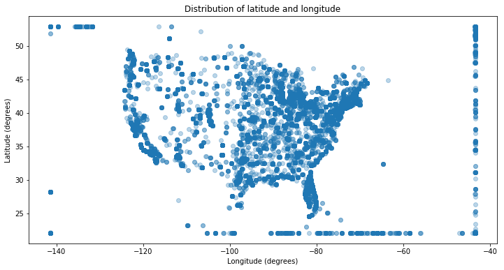

```python
plt.figure(figsize = [12, 6])
sb.regplot(data = bird_strike, x = 'LONGITUDE', y = 'LATITUDE', truncate = False, x_jitter = 0.03, fit_reg = False, scatter_kws = {'alpha':0.3});
plt.title('Distribution of latitude and longitude')
plt.xlabel('Longitude (degrees)')
plt.ylabel('Latitude (degrees)');
#The plot below shows the distributions of latitude and longitude
```

### Observation

The bulk of the distribution falls between -120 to -80 degrees for longitude and 30 to 45 degrees for latitude.

## Question 11: What size of species caused the most aircraft damages?

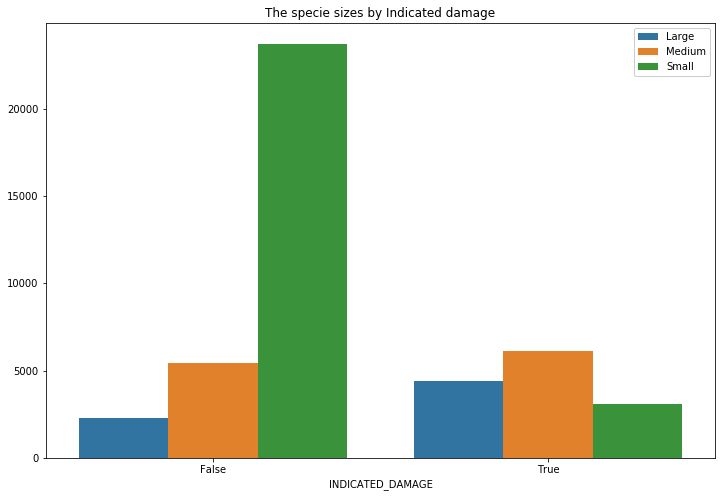

```python
plt.figure(figsize = [12, 8])

adapted_barchart(bird_strike, 'INDICATED_DAMAGE', 'SIZE', 1, 'The specie sizes by Indicated damage')
#The plot below shows the specie sizes by indicated damage
```

### Observation

The plot depicts two things:

- The small sized birds caused the most bird strikes while the large sized birds caused the least strikes.
- The medium sized birds caused the most aircraft damages while the small sized birds caused the least aircraft damages.

## Question 12: What is the time distribution across different months of the year?

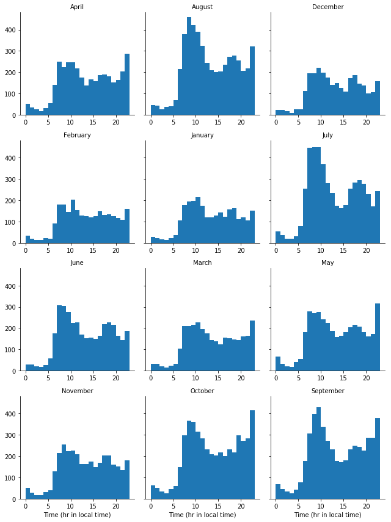

```python
def Facet_plot(df, var_x, m, var_y):
    bin_edges = np.arange(0, 23+1, 1)
    g = sb.FacetGrid(data = df, col = var_x, col_wrap = m, sharex = False)
    g.map(plt.hist, var_y, bins = bin_edges)
    g.set_xlabels('Time (hr in local time)')
    g.set_titles('{col_name}');

Facet_plot(bird_strike, 'MONTH_NAME', 3, 'TIME_HOUR')
#The plot below shows the time distribution across different months of the year
```

### Observation

The above plot depicts the following:

- June, July, August, September, November, and December most frequent time range falls between 8-10 am which is morning.
- January and February most frequent time range falls between 10-11 am which is also morning.
- April, October, March, and May time range falls between 22-23 pm which is night.

## Question 13: What is the time distribution across different years?

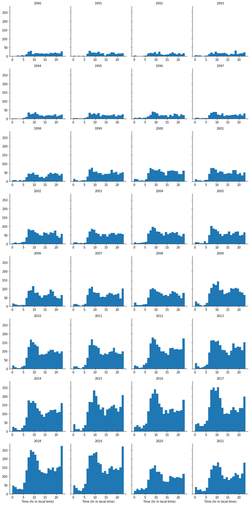

```python
Facet_plot(bird_strike, 'YEAR', 4, 'TIME_HOUR')
#The plot of time distribution across different years
```

### Talk about some of the relationships you observed in this part of the investigation. How did the feature(s) of interest vary with other features in the dataset?

> I found out from the bivariate exploration that the feature of interest (Indicated damage) gave different results for the most frequent season and size species for its false and true value. The false value showed that summer had the most bird strikes and the small sized birds caused the most bird strikes but there was no aircraft damage while the true value showed that fall had the most aircraft damages and the medium sized birds caused the most aircraft damages.

### Did you observe any interesting relationships between the other features (not the main feature(s) of interest)?

> The Year vs Time, Month vs Time and Latitude vs Longitude had interesting relationships. I discovered that bird strikes occur mostly between 8-10 am & 22-23 pm and at latitude of 30-45 degrees and -100 to -80 degrees.

## Multivariate Exploration

> Creating plots of three variables to further investigate the data.

## Question 14: Which bird species caused the most aircraft damage in terms of longitude and latitude?

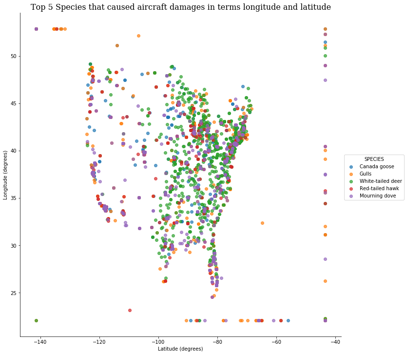

```python
#Function for threshold calculation
def feature_thres(m, df, var_x):
    Threshold = m
    freq = df[var_x].value_counts()
    freq_threshold = np.sum(freq > Threshold)
    feature_index = freq.index[:freq_threshold]
    var_sub = df.loc[df[var_x].isin(feature_index)]
    return var_sub

g = sb.FacetGrid(data = feature_thres(500, bird_strike_sub, 'SPECIES'), hue = 'SPECIES', size = 10)
g.map(sb.regplot, 'LONGITUDE', 'LATITUDE', truncate = False, x_jitter = 0.05, fit_reg = False, scatter_kws = {'alpha':0.7});
font = {'family':'serif','color':'black','weight':'normal','size':16}
g.add_legend()
g.set_xlabels('Latitude (degrees)')
g.set_ylabels('Longitude (degrees)');
plt.title('Top 5 Species that caused aircraft damages in terms longitude and latitude', fontdict = font);
#The plot of longitude and latitude distributions encoded with top five bird species
```

### Observation

From the plot above, it can be deduced that at a longitude of -100 to -80 and latitude of 30 to 45 degrees which has bulk of the points, Mourning dove and White-tailed deer caused the most bird strikes.

## Question 15: What is the time distribution for the different seasons in correlation with the variable of interest (Indicated damage)?

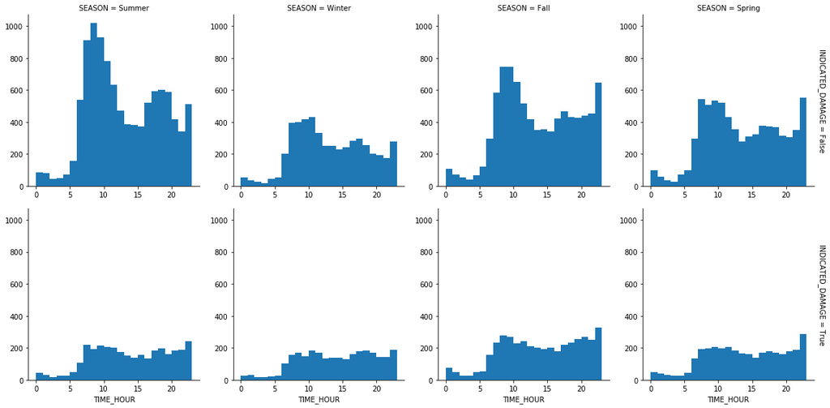

```python
xbin = np.arange(0, 23+1, 1)
g = sb.FacetGrid(data = bird_strike, col = 'SEASON', row = 'INDICATED_DAMAGE', size = 4, margin_titles = True)
g.map(plt.hist, 'TIME_HOUR', bins = xbin);
#The plot of time distribution for different seasons by indicated_damage
```

### Observation

Time distribution for seasons with the most bird strikes but no aircraft damages:

- Summer - 8 to 9 am
- Winter - 10 to 11 am
- Fall - 8 to 10 am
- Spring - 22 to 23 pm

Time distribution for seasons with the most aircraft damages:

- Summer, Winter, Fall, and Spring - 22 to 23 pm

## Question 16: List the top 20 airports and the size of species that caused most aircraft damages in terms of longitude and latitude

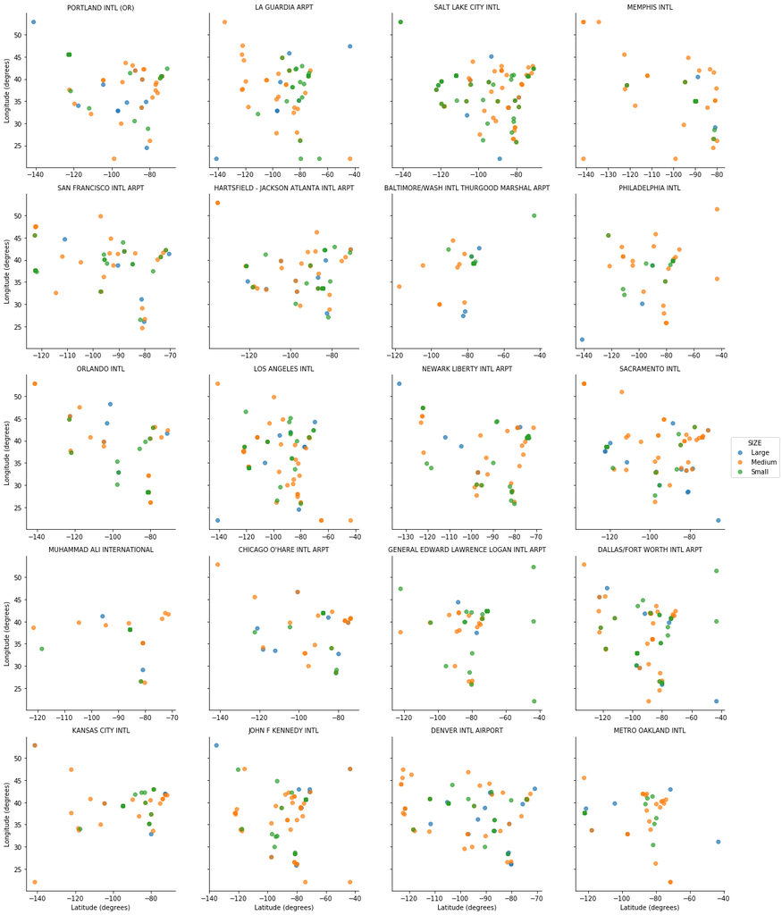

```python
g = sb.FacetGrid(data = feature_thres(115, bird_strike_sub, 'AIRPORT'), col = 'AIRPORT', hue = 'SIZE', size = 4, col_wrap = 4, sharex = False);
g.map(sb.regplot, 'LONGITUDE', 'LATITUDE', truncate = False, x_jitter = 0.05, fit_reg = False, scatter_kws = {'alpha':0.7});
g.set_xlabels('Latitude (degrees)')
g.set_ylabels('Longitude (degrees)')
g.set_titles('{col_name}');
g.add_legend();
#The plot of top 20 airports and its longitude and latitude distributions encoded with species sizes
```

### Observation

There were more of the orange points across the airports which indicates that the medium sized birds caused the most aircraft damages.

### Talk about some of the relationships you observed in this part of the investigation. Were there features that strengthened each other in terms of looking at your feature(s) of interest?

> Yes, the indicated damage, time and season strengthened each other and I got a clearer picture of the time distribution for the different seasons.

> A deeper look at the airports showed that the medium sized birds caused most aircraft damages. The Baltimore/Wash Intl Thurgood marshal and Muhammad Ali International Airport had the least points in terms of their longitude and latitude distribution.

### Were there any interesting or surprising interactions between features?

> I found it rather interesting that The top 2 species that caused the most aircraft damage in terms of longitude and latitude from the multivariate plot were Mourning dove and White-tailed deer while the top 2 species that caused aircraft damage from the univariate plot were gulls and white-tailed deer.

## Conclusions

- From the exploratory data analysis, **69.8%** of the bird strikes did not result in aircraft damage while **30.2%** of the bird strikes resulted to aircraft damage.
- The year **2018** and **2019** had the most bird strikes while **1992** had the least.
- **California** had the highest aircraft damages.
- Bird strike occur between **8-10 am** and **22-23 pm**.
- Top five bird species that caused most bird strikes are **mourning dove, gulls, barn swallow, european starling and horned lark** while **gulls, white-tailed deer, canada goose, mourning dove and red-tailed hawk** caused the most aircraft damages.
- Aircrafts with two engines were the most popular.
- **Salt Lake City, Sacramento and Dallas/Fort Worth International Airport** had the most aircraft damages.
- **Summer** had the most bird strikes while **Fall** had the most aircraft damages and **winter** was the season with the least that bird strikes and aircraft damages.
- **Medium sized birds** caused the most aircraft damages while the **small sized birds** caused the most bird strikes.